# Adolescents: health and family (wave 4)

Olga Lavrinenko

2022-12-12

```r
library(foreign)
library(descr)
```

```r
#setwd ("D:/Data Analytics For Politics And Society/Social and Political Attitudes (1-2 modules)/Project 2")
database <- read.spss ("alcohol_vocschool.sav",to.data.frame = T, use.value.labels = T)
```

# Pre-task:

## Before you begin, construct the distributions of the variables you are interested in and see if there are any unexpected answers that go beyond the categories of numbers indicated in the questionnaire.

```r
database$gender <-
  ifelse(database$gender == "0", "Girl",
  ifelse(database$gender == "1", "Boy", NA))
```

## The distributions of the variables

The distribution of the values of the variables we are interested in shows the absence of unexpected answers that could go beyond the categories of numbers indicated in the questionnaire.

1. For variables that illustrate the behavior of respondents (how often they drink and get drunk) 7 categories are provided:
   - 0. Never or almost never,
   - 1. 1 or 2 times in 6 months,
   - 2. 1 time per month or less,
   - 3. 2 - 3 times a month,
   - 4. 1 - 2 times a week,
   - 5. 3 to 5 times a week,
   - 6. Every day or almost every day.
2. There are two categories for variable “gender”:
   - 0 - Girl,
   - 1 - Boy
3. For variables that illustrate respondents’ attitudes 5 categories are provided:
   - 1 - Disagree,
   - 2 - Rather disagree,
   - 3 - Neither one nor the other,
   - 4 - Rather agree,
   - 5 - Agree.

```r
table(database$q32) #frequency_drink
```

```
##
##   0   1   2   3   4   5   6
## 374 277 192 244 111  29  24
```

```r
table(database$q33) #frequency_get_drunk
```

```
##
##   0   1   2   3   4   5   6
## 563 277 174 150  68  11  12
```

```r
table(database$gender) #gender
```

```
##
##  Boy Girl
##  817  440
```

```r
table(database$q25) #unpleasant_situation
```

```
##
##   1   2   3   4   5
## 343 160 188 246 311
```

```r
table(database$q26) #bad_relationship
```

```
##
##   1   2   3   4   5
## 399 216 239 144 251
```

```r
table(database$q29) #shame
```

```
##
##   1   2   3   4   5
## 398 215 254 139 237
```

## Renaming variables

Let’s change names of variables that will be used in this project.

```r
database$frequency_drink <- database$q32
database$frequency_get_drunk <- database$q33
database$unpleasant_situation <- database$q25
database$bad_relationship <- database$q26
database$shame <- database$q29
```

# Task 1. Construct a distribution of responses (in %) how often teenagers drink and get drunk.

## How often teenagers drink

```r
prop_frequency_drink <- round((prop.table(table(database$q32)) * 100), 3)
prop_frequency_drink
```

```
##
##      0      1      2      3      4      5      6
## 29.896 22.142 15.348 19.504  8.873  2.318  1.918
```

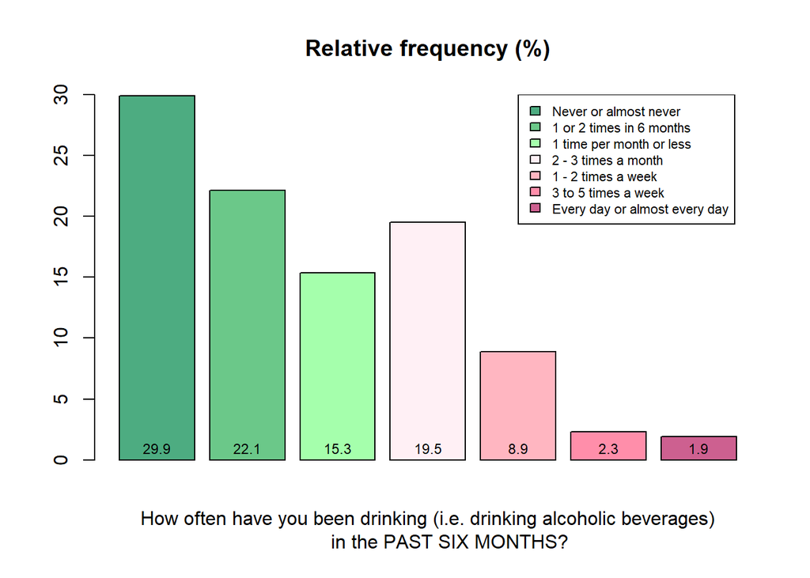

```r
bp_1 <- barplot(prop_frequency_drink,
        main = "Relative frequency (%)",
        xlab = "How often have you been drinking (i.e. drinking alcoholic beverages)
        in the PAST SIX MONTHS?",
        xaxt = "n",
        ylim = c(0, 30),
        col  = c("#4DAC81", "#6BC889", "#A5FFAC", "#FFF0F5", "#FFB6C1", "#FF8EAA", "#CD6090"))
legend(x = 5.5,
       y = 30,
       c("Never or almost never", "1 or 2 times in 6 months",
         "1 time per month or less", "2 - 3 times a month", "1 - 2 times a week",
         "3 to 5 times a week", "Every day or almost every day"),
       cex = 0.7,
      fill = c("#4DAC81", "#6BC889", "#A5FFAC", "#FFF0F5", "#FFB6C1", "#FF8EAA", "#CD6090"))
text(bp_1, -0.4, round(prop_frequency_drink, 1), cex = 0.75, col = "black", pos = 3)
```

## How often teenagers have get drunk

```r
prop_frequency_get_drunk <- round((prop.table(table(database$q33)) * 100), 3)
prop_frequency_get_drunk
```

```
##
##      0      1      2      3      4      5      6
## 44.861 22.072 13.865 11.952  5.418  0.876  0.956
```

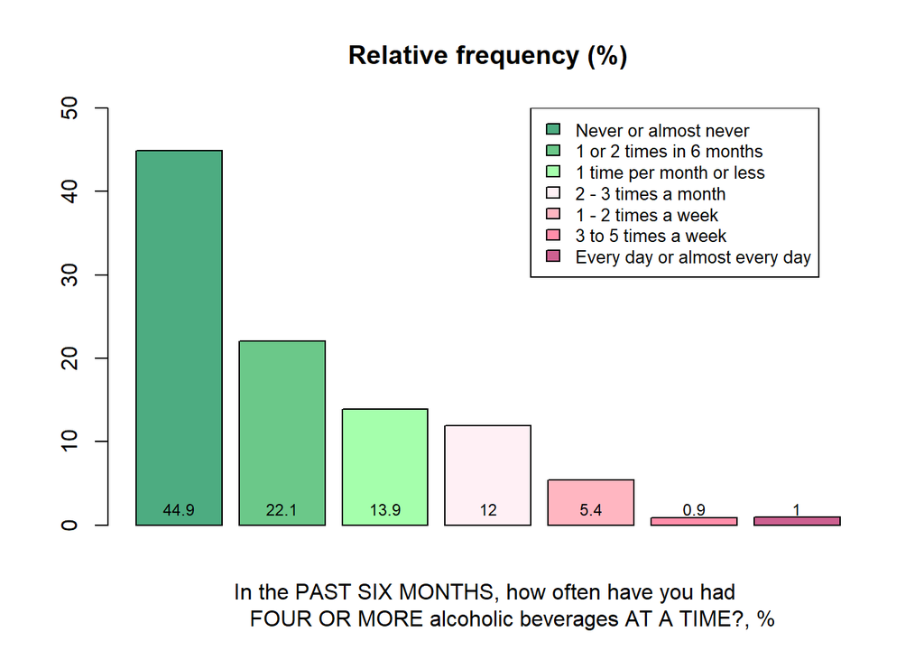

```r
bp_2 <- barplot(prop_frequency_get_drunk,
        main = "Relative frequency (%)",
        xlab = "In the PAST SIX MONTHS, how often have you had
        FOUR OR MORE alcoholic beverages AT A TIME?, %",
        xaxt = "n",
        ylim = c(0, 50),
        col  = c("#4DAC81", "#6BC889", "#A5FFAC", "#FFF0F5", "#FFB6C1", "#FF8EAA", "#CD6090"))
legend(x = 4.8,
       y = 50,
       c("Never or almost never", "1 or 2 times in 6 months",
         "1 time per month or less", "2 - 3 times a month", "1 - 2 times a week",
         "3 to 5 times a week", "Every day or almost every day"),
       cex  = 0.8,
       fill = c("#4DAC81", "#6BC889", "#A5FFAC", "#FFF0F5", "#FFB6C1", "#FF8EAA", "#CD6090"))
text(bp_2, -0.4, round(prop_frequency_get_drunk, 1), cex = 0.75, col = "black", pos = 3)
```

# Task 2. Compare both questions by gender.

## Gender differences: how often teenagers drink

1. the percentage of those who drink **no more than 2 times in a half-year** among boys is a bit higher compared to girls:
   - 54.2 % of boys drink never / almost never / 1 or 2 times in 6 months
   - 47.8 % of girls drink never / almost never / 1 or 2 times in 6 months
2. wherein the percentage of those who drink **no more than 3 times a month** among girls is higher compared to boys:
   - 42.0 % of girls drink 2 - 3 times a month /1 time per month or less
   - 31.1 % of boys drink 2 - 3 times a month /1 time per month or less
3. and the percentage of those who drink **at least once a week** among boys is higher compared to girls:
   - 14.6 % of boys drink 1 - 2 times a week / 3 to 5 times a week / every day or almost every day
   - 10.2 % of girls drink 1 - 2 times a week / 3 to 5 times a week / every day or almost every day

```r
prop_frequency_drink_Gender <-
  round((prop.table(table(database$gender, database$q32), 1) * 100), 3)
prop_frequency_drink_Gender
```

```
##
##             0      1      2      3      4      5      6
##   Boy  31.813 22.441 13.194 17.879  9.494  2.836  2.343
##   Girl 26.196 21.640 19.362 22.551  7.745  1.367  1.139
```

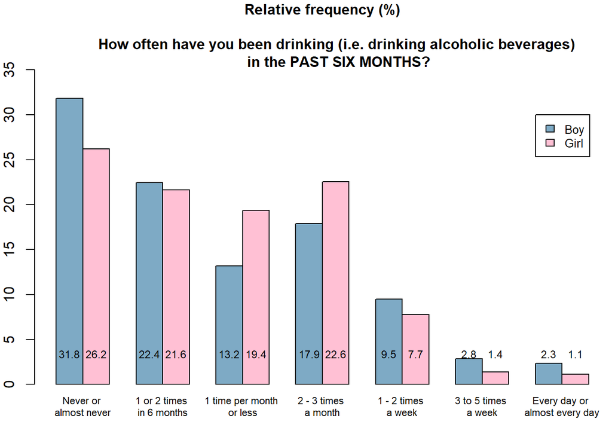

```r
par(mar = c(3, 2, 4, 0.1))
bp_3 <- barplot(prop_frequency_drink_Gender,
        beside = T,
        main = "Relative frequency (%)\n
        How often have you been drinking (i.e. drinking alcoholic beverages)
        in the PAST SIX MONTHS?",
        cex.main = 1,
        ylim = c(0, 35),
        col = c("#7EAAC5","#FFC0D4"),
        names.arg = c("Never or \nalmost never", "1 or 2 times \nin 6 months",
         "1 time per month \nor less", "2 - 3 times \na month", "1 - 2 times \na week",
         "3 to 5 times \na week", "Every day or \nalmost every day"),
        cex.names = 0.7)
legend(x = 19,
       y = 30,
       c("Boy", "Girl"),
       cex = 0.8,
       fill = c("#7EAAC5","#FFC0D4"))

text(bp_3, 2, round(prop_frequency_drink_Gender, 1), cex = 0.75, col = "black", pos=3)
```

## Gender differences: how often teenagers have get drunk

1. the percentage of those who get drunk **no more than 2 times in a half-year** among boys is approximately the same for boys and girls:
   - 67.7 % of girls get drunk never / almost never / 1 or 2 times in 6 months
   - 66.5 % of boys get drunk never / almost never / 1 or 2 times in 6 months
2. also, the percentage of those who get drunk **no more than 3 times a month** is approximately the same for boys and girls
   - 26.4 % of girls get drunk 2 - 3 times a month /1 time per month or less
   - 25.6 % of boys get drunk 2 - 3 times a month /1 time per month or less
3. and over again, the percentage of those who get drunk **at least once a week** is approximately the same for boys and girls:
   - 8 % of boys get drunk 1 - 2 times a week / 3 to 5 times a week / every day or almost every day
   - 5.9 % of girls get drunk 1 - 2 times a week / 3 to 5 times a week / every day or almost every day

So, there is no significant gender differences in the question of how often teenagers have get drunk.

```r
prop_frequency_get_drunk_Gender <-
  round((prop.table(table(database$gender, database$q33), 1) * 100), 3)
prop_frequency_get_drunk_Gender
```

```
##
##             0      1      2      3      4      5      6
##   Boy  45.455 21.007 13.391 12.162  5.528  1.106  1.351
##   Girl 43.636 24.091 14.773 11.591  5.227  0.455  0.227
```

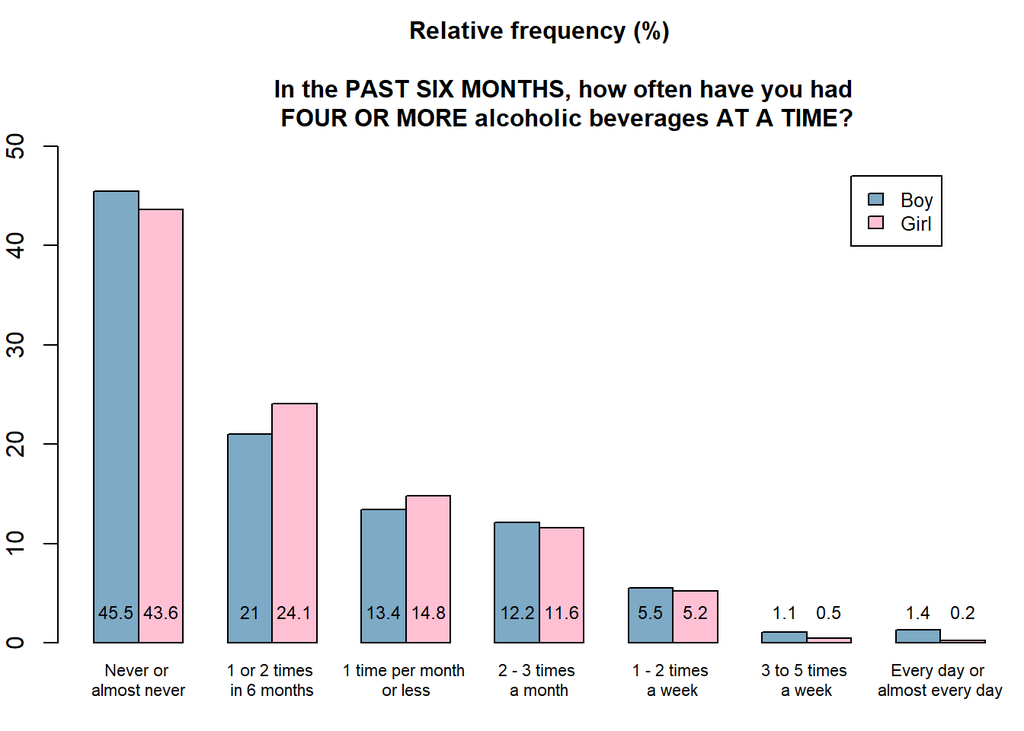

```r
par(mar = c(3, 2, 5, 0.1))
bp_4 <- barplot(prop_frequency_get_drunk_Gender,
        beside = T,
        main = "Relative frequency (%)\n
        In the PAST SIX MONTHS, how often have you had
        FOUR OR MORE alcoholic beverages AT A TIME?",
        cex.main = 1,
        ylim = c(0, 50),
        col = c("#7EAAC5", "#FFC0D4"),
        names.arg = c("Never or \nalmost never", "1 or 2 times \nin 6 months",
         "1 time per month \nor less", "2 - 3 times \na month", "1 - 2 times \na week",
         "3 to 5 times \na week", "Every day or \nalmost every day"),
        cex.names = 0.7)
legend(x = 18,
       y = 47,
       c("Boy", "Girl"),
       cex = 0.8,
       fill = c("#7EAAC5", "#FFC0D4"))
text(bp_4, 1, round(prop_frequency_get_drunk_Gender, 1), cex = 0.75, col = "black", pos = 3)
```

# Task 3. Show cross-tabulation of alcohol-specific attitudes and the frequency of drinking girls and boys.

## Renaming variables

First, let’s rename the variables and their values according to the questionnaire for clarity and more convenient interpretation. In addition, we will reduce the number of values for variables that reflect the attitudes. We will combine the categories Agree/Rather Agree into one category and Disagree/Rather Disagree into another. And also we will combine the categories of frequency of drinking and getting drunk.

```r
database$unpleasant_situation <-
  ifelse(database$unpleasant_situation =="1", "Disagree",
  ifelse(database$unpleasant_situation =="2", "Disagree",
  ifelse(database$unpleasant_situation =="3", "Neither agree nor disagree",
  ifelse(database$unpleasant_situation =="4", "Agree",
  ifelse(database$unpleasant_situation =="5", "Agree", NA)))))

database$bad_relationship <-
  ifelse(database$bad_relationship =="1", "Disagree",
  ifelse(database$bad_relationship =="2", "Disagree",
  ifelse(database$bad_relationship =="3", "Neither agree nor disagree",
  ifelse(database$bad_relationship =="4", "Agree",
  ifelse(database$bad_relationship =="5", "Agree", NA)))))

database$shame <-
  ifelse(database$shame =="1", "Disagree",
  ifelse(database$shame =="2", "Disagree",
  ifelse(database$shame =="3", "Neither agree nor disagree",
  ifelse(database$shame =="4", "Agree",
  ifelse(database$shame =="5", "Agree", NA)))))

database$frequency_drink <-
  ifelse(database$frequency_drink == "0", "No more than 2 times in a half-year",
  ifelse(database$frequency_drink == "1", "No more than 2 times in a half-year",
  ifelse(database$frequency_drink == "2", "No more than 3 times a month",
  ifelse(database$frequency_drink == "3", "No more than 3 times a month",
  ifelse(database$frequency_drink == "4", "At least once a week",
  ifelse(database$frequency_drink == "5", "At least once a week",
  ifelse(database$frequency_drink == "6", "At least once a week", NA)))))))

database$frequency_get_drunk <-
  ifelse(database$frequency_get_drunk == "0", "No more than 2 times in a half-year",
  ifelse(database$frequency_get_drunk == "1", "No more than 2 times in a half-year",
  ifelse(database$frequency_get_drunk == "2", "No more than 3 times a month",
  ifelse(database$frequency_get_drunk == "3", "No more than 3 times a month",
  ifelse(database$frequency_get_drunk == "4", "At least once a week",
  ifelse(database$frequency_get_drunk == "5", "At least once a week",
  ifelse(database$frequency_get_drunk == "6", "At least once a week", NA)))))))
```

To determine the association between variables we should calculate the **chi-square** and consider the values that we get.

## **Frequency drink and Gender**

1. Chi-square: p-value is significant (p = 0.000319), therefore we can point out to the association between gender and how often teenagers drink
2. Std Residuals: girls are likely to drink no more than 3 times a month (std. res > |1.96|, std. res = 2.495), while boys are not likely to drink no more than 3 times a month (std. res = -1.836). Other standardized residuals are not statistically significant.

```r
CrossTable(database$frequency_drink, database$gender,
           chisq = T, expected = T, sresid = T,
           prop.r = T, prop.c = F, prop.t = F, prop.chisq = F,
           dnn = c("How often do you drink?", "Gender"))
```

```
##    Cell Contents
## |-------------------------|
## |                       N |
## |              Expected N |
## |           N / Row Total |
## |            Std Residual |
## |-------------------------|
##
## ==============================================================
##                                        Gender
## How often do you drink?                   Boy     Girl   Total
## --------------------------------------------------------------
## At least once a week                      119       45     164
##                                         106.4     57.6
##                                         0.726    0.274   0.131
##                                         1.221   -1.660
## --------------------------------------------------------------
## No more than 2 times in a half-year       440      210     650
##                                         421.7    228.3
##                                         0.677    0.323   0.520
##                                         0.890   -1.210
## --------------------------------------------------------------
## No more than 3 times a month              252      184     436
##                                         282.9    153.1
##                                         0.578    0.422   0.349
##                                        -1.836    2.495
## --------------------------------------------------------------
## Total                                     811      439    1250
## ==============================================================
##
## Statistics for All Table Factors
##
## Pearson's Chi-squared test
## ------------------------------------------------------------
## Chi^2 = 16.09898      d.f. = 2      p = 0.000319
```

## **Frequency get drunk and Gender**

Chi-square: p-value is not significant (p = 0.399), therefore we can not point out to the association between gender and how often teenagers get drunk.

```r
CrossTable(database$frequency_get_drunk, database$gender,
           chisq = T, expected = T, sresid = T,
           prop.r = T, prop.c = F, prop.t = F, prop.chisq = F,
           dnn = c("How often have you get drink?", "Gender"))
```

```
##    Cell Contents
## |-------------------------|
## |                       N |
## |              Expected N |
## |           N / Row Total |
## |            Std Residual |
## |-------------------------|
##
## ==============================================================
##                                        Gender
## How often have you get drink?             Boy     Girl   Total
## --------------------------------------------------------------
## At least once a week                       65       26      91
##                                          59.1     31.9
##                                         0.714    0.286   0.073
##                                         0.772   -1.049
## --------------------------------------------------------------
## No more than 2 times in a half-year       541      298     839
##                                         544.6    294.4
##                                         0.645    0.355   0.669
##                                        -0.155    0.211
## --------------------------------------------------------------
## No more than 3 times a month              208      116     324
##                                         210.3    113.7
##                                         0.642    0.358   0.258
##                                        -0.160    0.217
## --------------------------------------------------------------
## Total                                     814      440    1254
## ==============================================================
##
## Statistics for All Table Factors
##
## Pearson's Chi-squared test
## ------------------------------------------------------------
## Chi^2 = 1.837548      d.f. = 2      p = 0.399
```

```r
CrossTable(database$frequency_drink, database$bad_relationship,
           chisq = T, expected = T, sresid = T,
           prop.r = T, prop.c = F, prop.t = F, prop.chisq = F,
           dnn = c("How often do you drink? ",
                   "Alcohol can get me into trouble"))
```

```
##    Cell Contents
## |-------------------------|
## |                       N |
## |              Expected N |
## |           N / Row Total |
## |            Std Residual |
## |-------------------------|
##
## ===============================================================================
##                            Alcohol can get me into trouble
## How often do you drink?     Agree   Disagree   Neither agree nor disgr    Total
## -------------------------------------------------------------------------------
## At least once a week           25        119                        19      163
##                              51.6       80.3                      31.2
##                             0.153      0.730                     0.117    0.131
##                            -3.701      4.325                    -2.178
## -------------------------------------------------------------------------------
## N mr thn 2 tms in a hl-       275        237                       134      646
##                             204.4      318.1                     123.5
##                             0.426      0.367                     0.207    0.519
##                             4.935     -4.546                     0.946
## -------------------------------------------------------------------------------
## No mor thn 3 tms a mnth        94        257                        85      436
##                             138.0      214.7                      83.3
##                             0.216      0.589                     0.195    0.350
##                            -3.744      2.889                     0.181
## -------------------------------------------------------------------------------
## Total                         394        613                       238     1245
## ===============================================================================
##
## Statistics for All Table Factors
##
## Pearson's Chi-squared test
## ------------------------------------------------------------
## Chi^2 = 105.4581      d.f. = 4      p <2e-16
```

```r
CrossTable(database$frequency_get_drunk, database$bad_relationship,
           chisq = T, expected = T, sresid = T,
           prop.r = T, prop.c = F, prop.t = F, prop.chisq = F,
           dnn = c("How often have you get drunk? ",
                   "Alcohol can get me into trouble"))
```

```
##    Cell Contents
## |-------------------------|
## |                       N |
## |              Expected N |
## |           N / Row Total |
## |            Std Residual |
## |-------------------------|
##
## ===============================================================================
##                            Alcohol can get me into trouble
## How often hv y gt drnk?     Agree   Disagree   Neither agree nor disgr    Total
## -------------------------------------------------------------------------------
## At least once a week           12         71                         7       90
##                              28.5       44.3                      17.2
##                             0.133      0.789                     0.078    0.072
##                            -3.086      4.009                    -2.463
## -------------------------------------------------------------------------------
## N mr thn 2 tms in a hl-       326        329                       180      835
##                             264.1      411.1                     159.8
##                             0.390      0.394                     0.216    0.669
##                             3.811     -4.051                     1.600
## -------------------------------------------------------------------------------
## No mor thn 3 tms a mnth        57        215                        52      324
##                             102.5      159.5                      62.0
##                             0.176      0.664                     0.160    0.259
##                            -4.492      4.391                    -1.270
## -------------------------------------------------------------------------------
## Total                         395        615                       239     1249
## ===============================================================================
##
## Statistics for All Table Factors
##
## Pearson's Chi-squared test
## ------------------------------------------------------------
## Chi^2 = 106.2222      d.f. = 4      p <2e-16
```

## **Frequency drink and Bad relationship**

1. Chi-square: p-value is significant (p <2e-16), therefore we can point out to the association between frequency of drinking and such attitude as “alcohol can ruin my relationship with family and friends”.
2. Std Residuals: respondents, who drink very rarely - no more than 2 times in a half-year, are likely (st.res = 4.935) to agree with the statement **“alcohol can ruin my relationship with family and friends”**, while those who drink at least once a week (st.res = 4.325) or several times a month (st.res = 2.889) are likely to disagree with this statement.

```r
CrossTable(database$frequency_drink, database$bad_relationship,
           chisq = T, expected = T, sresid = T,
           prop.r = T, prop.c = F, prop.t = F, prop.chisq = F,
           dnn = c("How often do you drink? ",
                   "Alcohol can ruin my relationship with family and friends"))
```

```
##    Cell Contents
## |-------------------------|
## |                       N |
## |              Expected N |
## |           N / Row Total |
## |            Std Residual |
## |-------------------------|
##
## ===============================================================================
##                            Alcohol can ruin my relationship with family and friends
## How often do you drink?     Agree   Disagree   Neither agree nor disgr    Total
## -------------------------------------------------------------------------------
## At least once a week           25        119                        19      163
##                              51.6       80.3                      31.2
##                             0.153      0.730                     0.117    0.131
##                            -3.701      4.325                    -2.178
## -------------------------------------------------------------------------------
## N mr thn 2 tms in a hl-       275        237                       134      646
##                             204.4      318.1                     123.5
##                             0.426      0.367                     0.207    0.519
##                             4.935     -4.546                     0.946
## -------------------------------------------------------------------------------
## No mor thn 3 tms a mnth        94        257                        85      436
##                             138.0      214.7                      83.3
##                             0.216      0.589                     0.195    0.350
##                            -3.744      2.889                     0.181
## -------------------------------------------------------------------------------
## Total                         394        613                       238     1245
## ===============================================================================
##
## Statistics for All Table Factors
##
## Pearson's Chi-squared test
## ------------------------------------------------------------
## Chi^2 = 105.4581      d.f. = 4      p <2e-16
```

## **Frequency get drunk and Bad relationship**

1. Chi-square: p-value is significant (p <2e-16), therefore we can point out to the association between frequency of getting drunk and such attitude as “alcohol can ruin my relationship with family and friends”.
2. Std Residuals: respondents, who get drunk very rarely - no more than 2 times in a half-year, are likely (st.res = 3.811) to agree with the statement **“alcohol can ruin my relationship with family and friends”**, while those who get drunk at least once a week (st.res = 4.009) or several times a month (st.res = 4.391) are likely to disagree with this statement.

```r
CrossTable(database$frequency_get_drunk, database$bad_relationship,
           chisq = T, expected = T, sresid = T,
           prop.r = T, prop.c = F, prop.t = F, prop.chisq = F,
           dnn = c("How often have you get drunk? ",
                   "Alcohol can ruin my relationship with family and friends"))
```

```
##    Cell Contents
## |-------------------------|
## |                       N |
## |              Expected N |
## |           N / Row Total |
## |            Std Residual |
## |-------------------------|
##
## ===============================================================================
##                            Alcohol can ruin my relationship with family and friends
## How often hv y gt drnk?     Agree   Disagree   Neither agree nor disgr    Total
## -------------------------------------------------------------------------------
## At least once a week           12         71                         7       90
##                              28.5       44.3                      17.2
##                             0.133      0.789                     0.078    0.072
##                            -3.086      4.009                    -2.463
## -------------------------------------------------------------------------------
## N mr thn 2 tms in a hl-       326        329                       180      835
##                             264.1      411.1                     159.8
##                             0.390      0.394                     0.216    0.669
##                             3.811     -4.051                     1.600
## -------------------------------------------------------------------------------
## No mor thn 3 tms a mnth        57        215                        52      324
##                             102.5      159.5                      62.0
##                             0.176      0.664                     0.160    0.259
##                            -4.492      4.391                    -1.270
## -------------------------------------------------------------------------------
## Total                         395        615                       239     1249
## ===============================================================================
##
## Statistics for All Table Factors
##
## Pearson's Chi-squared test
## ------------------------------------------------------------
## Chi^2 = 106.2222      d.f. = 4      p <2e-16
```

## **Frequency drink and Shame**

1. Chi-square: p-value is significant (p <2e-16), therefore we can point out to the association between frequency of drinking and such attitude as “I can be ashamed because of alcohol”.
2. Std Residuals: respondents, who drink very rarely - no more than 2 times in a half-year, are likely (st.res = 7.251) to agree with the statement **“I can be ashamed because of alcohol”**, while those who drink at least once a week (st.res = 5.088) or several times a month (st.res = 4.881) are likely to disagree with this statement.

```r
CrossTable(database$frequency_drink, database$shame,
           chisq = T, expected = T, sresid = T,
           prop.r = T, prop.c = F, prop.t = F, prop.chisq = F,
           dnn = c("How often do you drink? ",
                   "I can be ashamed because of alcohol"))
```

```
##    Cell Contents
## |-------------------------|
## |                       N |
## |              Expected N |
## |           N / Row Total |
## |            Std Residual |
## |-------------------------|
##
## ===============================================================================
##                            I can be ashamed because of alcohol
## How often do you drink?     Agree   Disagree   Neither agree nor disgr    Total
## -------------------------------------------------------------------------------
## At least once a week           14        126                        23      163
##                              49.3       80.4                      33.3
##                             0.086      0.773                     0.141    0.132
##                            -5.031      5.088                    -1.783
## -------------------------------------------------------------------------------
## N mr thn 2 tms in a hl-       295        199                       147      641
##                             194.0      316.1                     130.9
##                             0.460      0.310                     0.229    0.517
##                             7.251     -6.586                     1.408
## -------------------------------------------------------------------------------
## No mor thn 3 tms a mnth        66        286                        83      435
##                             131.7      214.5                      88.8
##                             0.152      0.657                     0.191    0.351
##                            -5.722      4.881                    -0.618
## -------------------------------------------------------------------------------
## Total                         375        611                       253     1239
## ===============================================================================
##
## Statistics for All Table Factors
##
## Pearson's Chi-squared test
## ------------------------------------------------------------
## Chi^2 = 209.2584      d.f. = 4      p <2e-16
```

## **Frequency get drunk and Shame**

```r
CrossTable(database$frequency_get_drunk, database$shame,
           chisq = T, expected = T, sresid = T,
           prop.r = T, prop.c = F, prop.t = F, prop.chisq = F,
           dnn = c("How often have you get drunk? ",
                   "I can be ashamed because of alcohol"))
```

```
##    Cell Contents
## |-------------------------|
## |                       N |
## |              Expected N |
## |           N / Row Total |
## |            Std Residual |
## |-------------------------|
##
## ===============================================================================
##                            I can be ashamed because of alcohol
## How often hv y gt drnk?     Agree   Disagree   Neither agree nor disgr    Total
## -------------------------------------------------------------------------------
## At least once a week            6         72                        12       90
##                              27.2       44.4                      18.4
##                             0.067      0.800                     0.133    0.072
##                            -4.068      4.145                    -1.490
## -------------------------------------------------------------------------------
## N mr thn 2 tms in a hl-       331        315                       184      830
##                             251.1      409.3                     169.6
##                             0.399      0.380                     0.222    0.668
##                             5.044     -4.662                     1.105
## -------------------------------------------------------------------------------
## No mor thn 3 tms a mnth        39        226                        58      323
##                              97.7      159.3                      66.0
##                             0.121      0.700                     0.180    0.260
##                            -5.939      5.286                    -0.985
## -------------------------------------------------------------------------------
## Total                         376        613                       254     1243
## ===============================================================================
##
## Statistics for All Table Factors
##
## Pearson's Chi-squared test
## ------------------------------------------------------------
## Chi^2 = 148.5333      d.f. = 4      p <2e-16
```

## **Unpleasant situation and Gender**

Chi-square: p-value is not significant (p = 0.524), therefore we can not point out to the association between gender and such attitude as “alcohol can get me into trouble”.

```r
CrossTable(database$unpleasant_situation, database$gender,
           chisq = T, expected = T, sresid = T,
           prop.r = T, prop.c = F, prop.t = F, prop.chisq = F,
           dnn = c("Alcohol can get me into trouble", "Gender"))
```

```
##    Cell Contents
## |-------------------------|
## |                       N |
## |              Expected N |
## |           N / Row Total |
## |            Std Residual |
## |-------------------------|
##
## ==========================================================
##                                    Gender
## Alcohol can get me into trouble       Boy     Girl   Total
## ----------------------------------------------------------
## Agree                                 361      196     557
##                                     361.8    195.2
##                                     0.648    0.352   0.447
##                                    -0.042    0.058
## ----------------------------------------------------------
## Disagree                              321      182     503
##                                     326.7    176.3
##                                     0.638    0.362   0.403
##                                    -0.317    0.431
## ----------------------------------------------------------
## Neither agree nor disagree            128       59     187
##                                     121.5     65.5
##                                     0.684    0.316   0.150
##                                     0.593   -0.807
## ----------------------------------------------------------
## Total                                 810      437    1247
## ==========================================================
##
## Statistics for All Table Factors
##
## Pearson's Chi-squared test
## ------------------------------------------------------------
## Chi^2 = 1.294162      d.f. = 2      p = 0.524
```

## **Bad relationship and Gender**

Chi-square: p-value is not significant (p = 0.676), therefore we can not point out to the association between gender and such attitude as “alcohol can ruin my relationship with family and friends”.

```r
CrossTable(database$bad_relationship, database$gender,
           chisq = T, expected = T, sresid = T,
           prop.r = T, prop.c = F, prop.t = F, prop.chisq = F,
           dnn = c("Alcohol can ruin my relationship with family and friends", "Gender"))
```

```
##    Cell Contents
## |-------------------------|
## |                       N |
## |              Expected N |
## |           N / Row Total |
## |            Std Residual |
## |-------------------------|
##
## ===================================================================================
##                                                             Gender
## Alcohol can ruin my relationship with family and friends       Boy     Girl   Total
## -----------------------------------------------------------------------------------
## Agree                                                          262      132     394
##                                                              255.7    138.3
##                                                              0.665    0.335   0.316
##                                                              0.393   -0.534
## -----------------------------------------------------------------------------------
## Disagree                                                       397      218     615
##                                                              399.2    215.8
##                                                              0.646    0.354   0.493
##                                                             -0.108    0.147
## -----------------------------------------------------------------------------------
## Neither agree nor disagree                                     151       88     239
##                                                              155.1     83.9
##                                                              0.632    0.368   0.192
##                                                             -0.331    0.450
## -----------------------------------------------------------------------------------
## Total                                                          810      438    1248
## ===================================================================================
##
## Statistics for All Table Factors
##
## Pearson's Chi-squared test
## ------------------------------------------------------------
## Chi^2 = 0.7843572      d.f. = 2      p = 0.676
```

## **Shame and Gender**

Chi-square: p-value is not significant (p = 0.856), therefore we can not point out to the association between gender and such attitude as “I can be ashamed because of alcohol”.

```r
CrossTable(database$shame, database$gender,
           chisq = T, expected = T, sresid = T,
           prop.r = T, prop.c = F, prop.t = F, prop.chisq = F,
           dnn = c("I can be ashamed because of alcohol", "Gender"))
```

```
##    Cell Contents
## |-------------------------|
## |                       N |
## |              Expected N |
## |           N / Row Total |
## |            Std Residual |
## |-------------------------|
##
## ==============================================================
##                                        Gender
## I can be ashamed because of alcohol       Boy     Girl   Total
## --------------------------------------------------------------
## Agree                                     241      135     376
##                                         243.7    132.3
##                                         0.641    0.359   0.303
##                                        -0.173    0.235
## --------------------------------------------------------------
## Disagree                                  402      211     613
##                                         397.3    215.7
##                                         0.656    0.344   0.494
##                                         0.235   -0.319
## --------------------------------------------------------------
## Neither agree nor disagree                162       91     253
##                                         164.0     89.0
##                                         0.640    0.360   0.204
##                                        -0.155    0.210
## --------------------------------------------------------------
## Total                                     805      437    1242
## ==============================================================
##
## Statistics for All Table Factors
##
## Pearson's Chi-squared test
## ------------------------------------------------------------
## Chi^2 = 0.3103214      d.f. = 2      p = 0.856
```

# Task 4. Explain this distribution.

However, we found no association between gender and negative attitudes towards alcohol, nor between gender and frequency of getting drunk.

Thus, based on the analysis, we can not conclude whether attitudes determine the behavior of a teenager in relation to alcohol, or maybe the negative experience of drinking alcohol forms such negative social attitudes. However, it can be argued that there is an association between behavior and attitudes about social consequences of drinking.